# Inferenza

Patrizio Frederic

2025-04-27

# Inferire

Dalla Treccani si definisce l’atto di inferire come:

> Trarre, partendo da una determinata premessa o dalla constatazione di un fatto, una conseguenza, un giudizio, una conclusione.

# Inferire: un atto cognitivo fondamentale

- Inferire = trarre conclusioni da osservazioni o idee
- Collega idee ed esperienze con altre idee
- Richiede riconoscimento, elaborazione, astrazione

# Inferenza nel mondo animale

- Alcune specie evolute apprendono regolarità dall’ambiente
- Adattano il comportamento in base all’esperienza
- Inferenza implicita, non consapevole

# Dalla contingenza all’astrazione

- Se succede questa condizione → adotto questo comportamento
- Perché succede questa condizione?
- Cosa succederebbe se adottassi un altro comportamento?
- Se succedesse questa situazione ipotetica?
- Cosa succederebbe se in una data situazione ipotetica adottassi un dato comportamento ipotetico?

# Specificità umana dell’inferenza

- L’uomo prende coscienza dell’atto inferenziale
- Costruisce linguaggi simbolici e modelli astratti
- Nascono logica, matematica, statistica
- L’inferenza diventa replicabile e comunicabile

# Tre modalità di inferenza: Deduttiva

- Deduttiva: da premesse date a conclusioni necessarie
  - Se $A\Rightarrow B$ e $B\Rightarrow C$, allora $A\Rightarrow C$
  - Socrate è un uomo ($S\Rightarrow U$) → **Tutti** gli uomini sono mortali ($U\Rightarrow M$) → Socrate è mortale ($S\Rightarrow M$)
  - Michele è una mucca → **Tutte** le mucche hanno le ali → Michele ha le ali
  - Se $x>2$ allora $x^2>4$ → $x=3$ → $x^2=9>4$
  - Se $P(B|A)=1$, e $P(C|B)=1$ allora $P(C|A)=1$

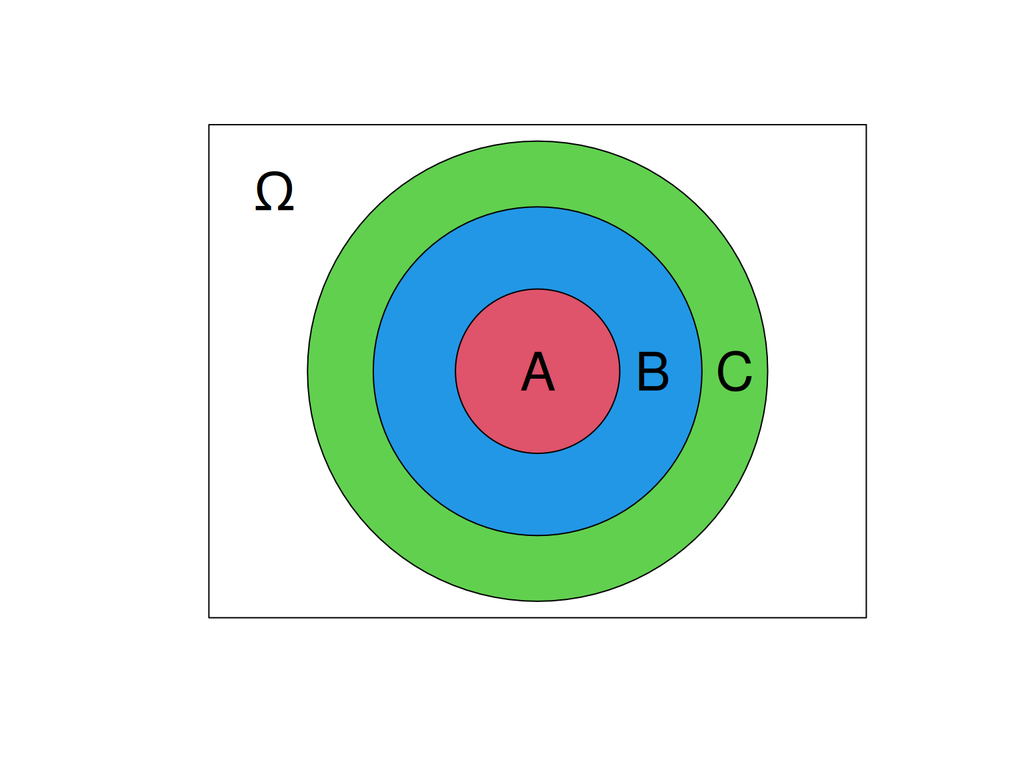

# Tre modalità di inferenza: Induttiva

- Induttiva diretta: da modello noto a probabilità di osservazioni
  - questa è una pallina → **Alcune** palline sono vincenti → $0 < P(\text{Pallina Vincente}) < 1$
  - Michele è un uomo → **Alcuni** uomini hanno l’allele APOE $\varepsilon4$ → $0 < P(\text{APOE }\varepsilon4 ) < 1$
- Induttiva inversa (**Inferenza Statistica**): da dati osservati a modello incognito
  - Estraggo 10 palline → 6 palline sono vincenti → com’è composta l’urna?
  - Osservo 100 persone → 53 hanno l’allele APOE $\varepsilon4$ → com’è composta l’urna?
  - Estraggo 10 palline da un’urna e 10 dall’altra → 6 sono vincenti dalla prima e 4 dalla seconda → le due urne sono uguali?
  - Osservo 50 anziani con l’Alzheimer e 50 anziani senza → 40 su 50 tra chi ha l’Alzheimer ha l’allele APOE $\varepsilon4$, 24 su 50 tra chi non ha l’Alzheimer ha l’allele APOE $\varepsilon4$ → i due gruppi sono uguali?

# Dalla probabilità all’inferenza

- Esistono diversi approcci filosofico/concettuali
- Dipende dalla definizione di probabilità
- La probabilità in senso frequentista:
  - La probabilità vera esiste ma è incognita
  - Il vero $\pi$ di un’urna esiste ma è incognito
  - La probabilità si applica solo agli esperimenti ripetibili (come le estrazioni)
  - $\pi$ non è oggetto di estrazione casuale, non posso usare la probabilità per descrivere la mia incertezza
  - La probabilità non basta: per fare inferenza servono nuovi concetti → statistica classica
- La probabilità in senso soggettivista:
  - La probabilità è un modo per modellare l’incertezza soggettiva
  - Qualsiasi cosa ignota può essere trattata come aleatoria
  - Siccome $\pi$ è incognito lo modello come una VC
  - La probabilità contiene anche l’inferenza statistica → statistica bayesiana

# Statistica Classica vs Statistica Bayesiana

- Statistica Classica
  - È il più diffusa nelle applicazioni e nelle discipline scientifiche
  - È storicamente consolidata (Fisher, Neyman, Pearson…)
  - Resta il termine di confronto per ogni alternativa
- Statistica Bayesiana
  - È ancora emergente nelle applicazioni
  - È dibattuta perché introduce elementi soggettivi in modo esplicito
  - È spesso studiata in contrapposizione alla statistica classica, in corsi più avanzati
  - Estende e generalizza i risultati della statistica classica

# Campione e Campionamento

- Tutta l’inferenza parte dall’osservazione di un campione
- Il campione è al fonte principale di informazione
- Rappresenta (idealmente) qualcosa di più grande

# Campioni Casuali

- La casualità nella selezione garantisce generalizzabilità
- Senza casualità: rischio di distorsione sistematica
- La probabilità permette di misurare l’incertezza

# Inferenza da popolazioni finite

- Popolazioni chiuse, elencabili (es. censimenti)
- Necessario un registro completo della popolazione
- Richiede disegno campionario, strumenti di rilevazione, controllo qualità
- Tipica delle statistiche ufficiali (ISTAT, Eurostat, OCSE)

# Esempi di indagini su popolazioni finite

- Forze di lavoro (ISTAT): tasso di occupazione, 77 000 famiglie/trim.
- Consumi delle famiglie (ISTAT): diario spese, 30 000 famiglie/anno
- EU-SILC (Eurostat/ISTAT): redditi e disuguaglianze, >20 000 famiglie
- PISA (OCSE): competenze studenti quindicenni, 11 000 studenti/3 anni
- PIAAC (OCSE): competenze adulti 16-65 anni, 5 000 individui
- TALIS (OCSE): condizioni di lavoro degli insegnanti, 3 000 insegnanti

# Inferenza da popolazioni infinite

- Popolazioni non enumerate, concettualmente infinite
- I dati sono realizzazioni di una variabile aleatoria
- Si adotta un approccio modellistico probabilistico

# Esempi di popolazioni non enumerate

- I consumatori abituali degli spaghetti Barilla
- Le aziende con un gestionale più vecchio di 10 anni
- Le formiche presenti in una foresta tropicale
- I malati di diabete nel mondo

# Esempi di inferenza da popolazioni infinite

- Processi fisici e ambientali (es. temperatura, inquinanti)
- Produzione industriale (pezzi futuri)
- Eventi ripetibili (click, richieste a server)

# Inferenza non parametrica e parametrica

- Non parametrica: osservazioni IID, nessuna ipotesi sulla distribuzione
- Parametrica: ipotesi su una famiglia di distribuzioni
- Scelta = compromesso tra flessibilità e precisione